# GCDS: Data Visualization and the Grammar of Graphics

# **Adding Layers To Plots**

You can *add* a layer to a plot using `+`. Unlike `%>%`, you are not passing the object to another function but rather you are taking the current plot object and adding to it another layer.

For example:

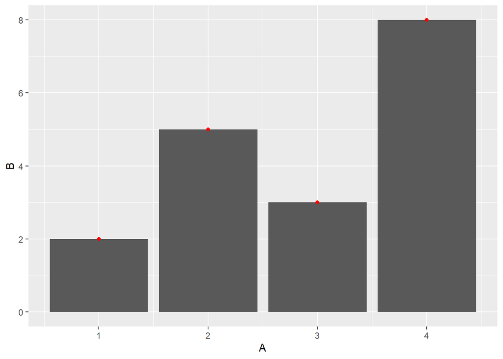

```r
DATA %>%
  ggplot(., aes(x = A, y = B)) +
  geom_col() +
  geom_point(color = "red")
```

## *Adding layers that inherit aesthetics*

When aesthetics are mapped to the initialized `ggplot()` object, the `x` and `y` variables therein carry through to the geometries. This is not a problem when the geometries are using similar information as with `geom_point()`, `geom_line()`, and even `geom_col()`.

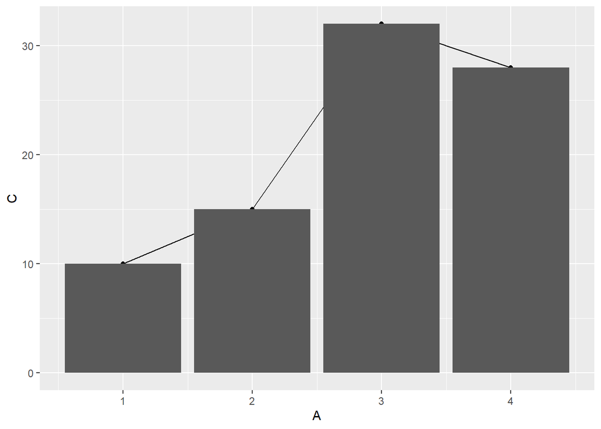

```r
map <- ggplot(data = DATA,
              mapping = aes(A, C))

map +
  geom_point() +
  geom_line() +
  geom_col()
```

But because `geom_bar()` takes only `x` or `y`, there will be a problem. Test it on your own.

## Adding layers that do not that inherit aesthetics

When aesthetics are not inherited by the initial object, they can be set or mapped in their own geometry. This example does not even pass `data = DATA`. If it did and each geometry used `DATA`, then that doesn’t need passing. Only omitted characteristics need mapping.

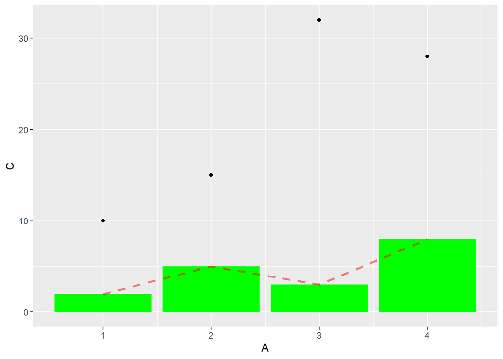

```r
map <- ggplot()

map +
  geom_point(data = DATA,
             mapping = aes(A, C)) +
  geom_col(data = DATA,
           mapping = aes(A, B),
           fill = "green") +
  geom_line(data = DATA,
            mapping = aes(A, B),
            linetype = "dashed",
            color = "red",
            size = 1,
            alpha = .5)
```

By specifying `DATA` and `aes(A, B)`, all geometries using `DATA` with `x = A` and `y = B` will inherit them. Otherwise, pass the necessary arguments to the geometries.

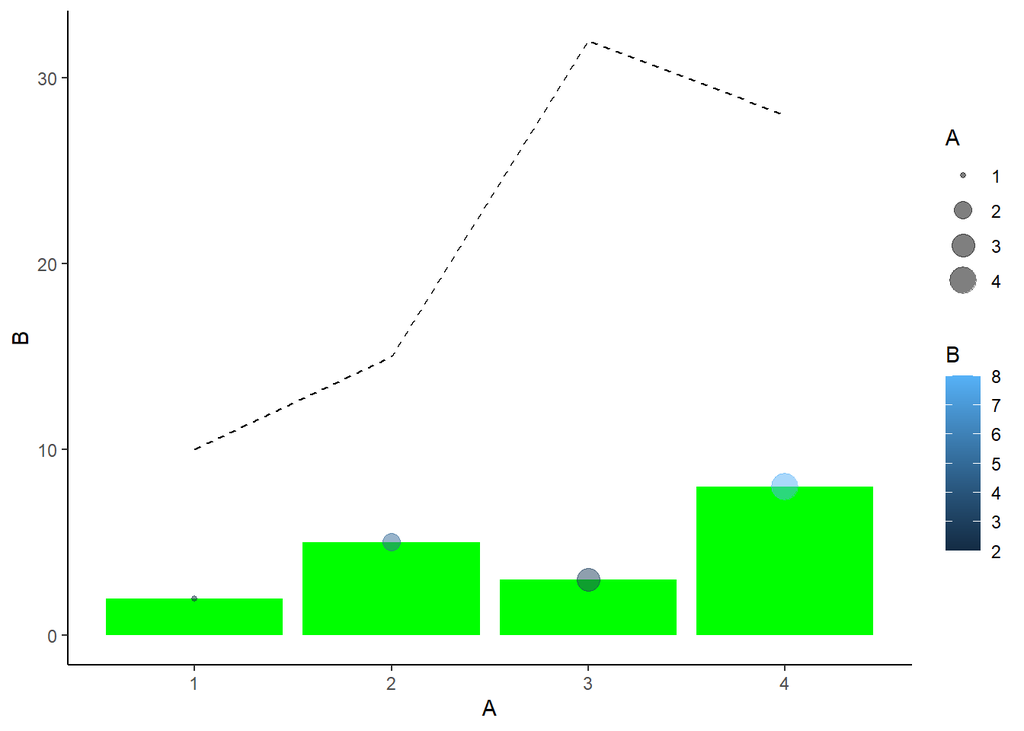

```r
map <- ggplot(data = DATA,
              mapping = aes(A, B))

map +
  geom_col(fill = "green") +            # set all columns to blue
  geom_line(mapping = aes(y = C),      # a new mapping y = C for the line data
            linetype = "dashed") +     # set the linetype

  geom_point(mapping = aes(color = B,  # map color to A (inherited as y)
                           size = A),  # map size to B (inherited as x)
            alpha = .5                 # set alpha transparency
            ) +
  theme_classic()
```

Now, this plot is certainly not the best and it certainly needs work. But the coding of the plot illustrates the flexibility of ggplot for adding plot geometry layers to a single plot, utilizing aesthetics inherited from an initialized object, mapping new aesthetics not inherited, setting aesthetic constants, and mapping variables to aesthetics.

```r
 geom_point(aes(sugars, rating))
```

```
## mapping: x = ~sugars, y = ~rating
## geom_point: na.rm = FALSE
## stat_identity: na.rm = FALSE
## position_identity
```

# **Position Adjustment to Address Overplotting**

The plot layer we did not yet address is position. In order for a point plot, bar plot, box plot or other plot to appear, they have to take a position in that space. An example involving points will help illustrate.

When plotting points on a plot, no matter what coordinate system you plot in, an xy coordinate will take a particular position in visual space. Following a Cartesian coordinate system, I’m sue you could imagine visually a point on a plot at position x = 3, y = 5. A data visualization problem occurs when two or more points also take that same xy position. Can you imagine 2 points in that same position? How about 5? Or even 11? You see the problem.

When you have many data points in a plot, they will overlap if they share a position, thus masking each other. When one point is hidden behind another point, viewers cannot see that there are multiple points. And in a worst-case scenario, those overlapping points are interpreted as a single point, leading to incorrect data storytelling or memory for said story. This description illustrates what is referred to as *overplotting*.

As a data storyteller, you have to deal with overplotting somehow. If you have an audience, you could explain this problem during a talk or in a write up. But a picture speaks a thousand words, if you let it. Because we are on the topic of data visualization, we could just address this overplotting issue by simply changing the position of the points slightly using some stochastic process (won’t be the same for each plot). For an x = 3, y = 5 point, how can we change the position slightly so it doesn’t overlap with another point at the same position? Well, maybe by adding some noise to the data, one point could be positioned at 3.1, 5.0 and another and 3.0, 5.1, and another at 3.1, 4.9, and another at 2.9, 5.1, etc. What you might imagine is a cluster of points around space x = 3, y = 5, each taking a slightly different position so that they don’t overlap and are all visible.

A good example of dealing with overplotting was seen in the first plot. Without adding any noise to the data (e.g., `position = "jitter"`) and changing `alpha`, the `mpg` for each cylinder level are plotted on top of each other

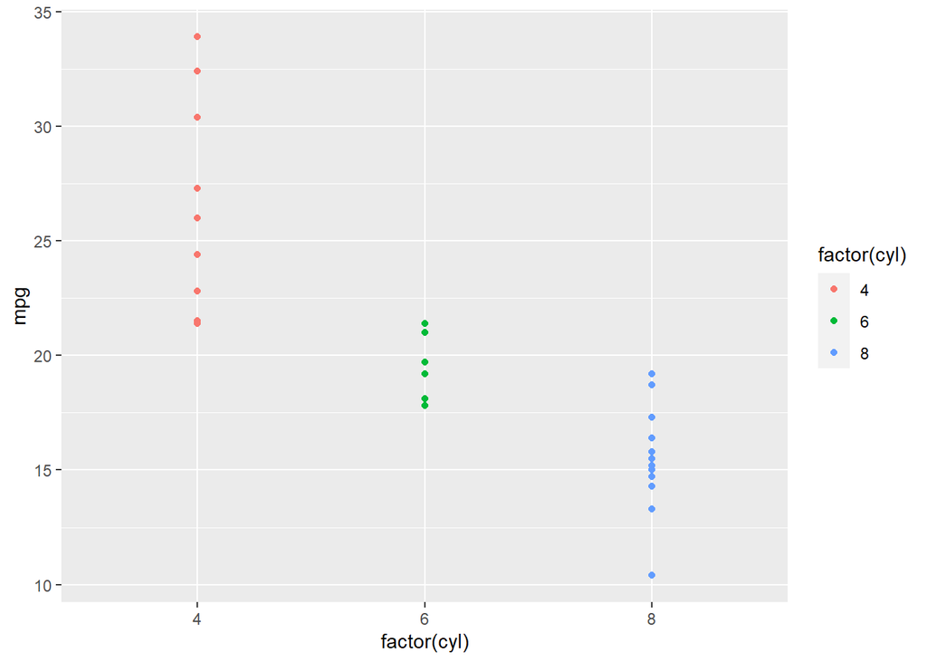

```r
ggplot(mtcars) +
  geom_point(aes(x = factor(cyl),
                 y = mpg,
                 color = factor(cyl))
             )
```

Changing the positioning by “jittering” them will make them cluster around their levels but visibly differentiated from each other. To facilitate the visual, we could change `alpha` to make the points somewhat transparent such that the overlap is darkend.

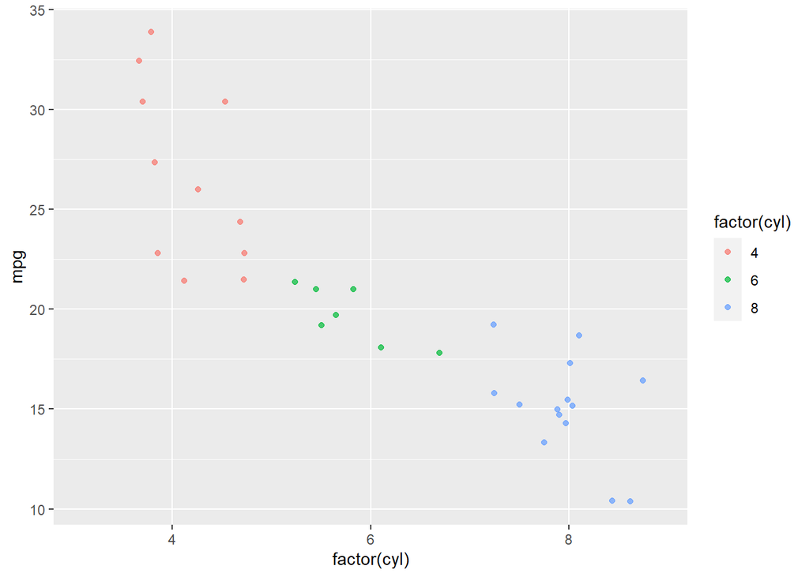

```r
ggplot(mtcars) +
  geom_point(aes(x = factor(cyl),
                 y = mpg,
                 color = factor(cyl)),
             position = "jitter",
             alpha = .7
             )
```

# **Facetting Plots**

When you want to plot the same data separately for levels or variations in another variable, you can plot facets. Using `facet_wrap()`, we can pass the `D` variable like this: `facet_wrap(~D)`

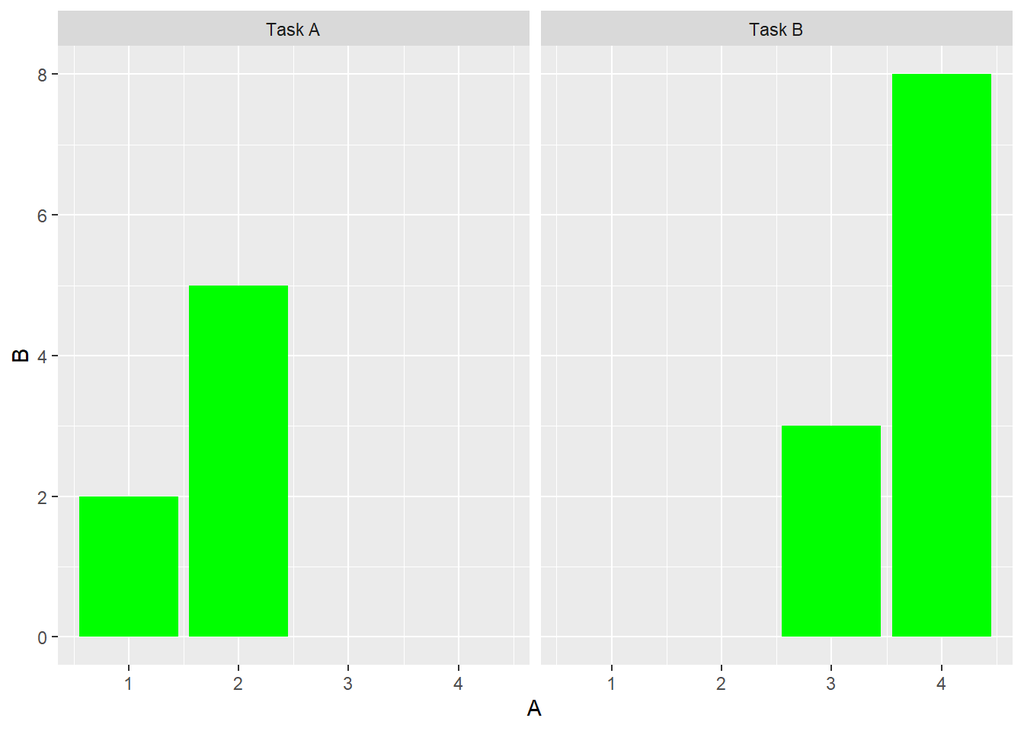

```r
DATA %>%
  ggplot() +
  geom_col(mapping = aes(A, B),
           fill = "green") +
  facet_wrap(~D)
```

Unfortunately, with this small data set, values differ in `A` based on `D` (the task) so you might be confused. Rest assured the function is doing what it should. Our data only have responses 1 and 2 for Task A and 3 and 4 for Task B. Perhaps a better illustration is with `mtcars` data. A point plot visualizing `wt` and `mpg` for each cylinder size.

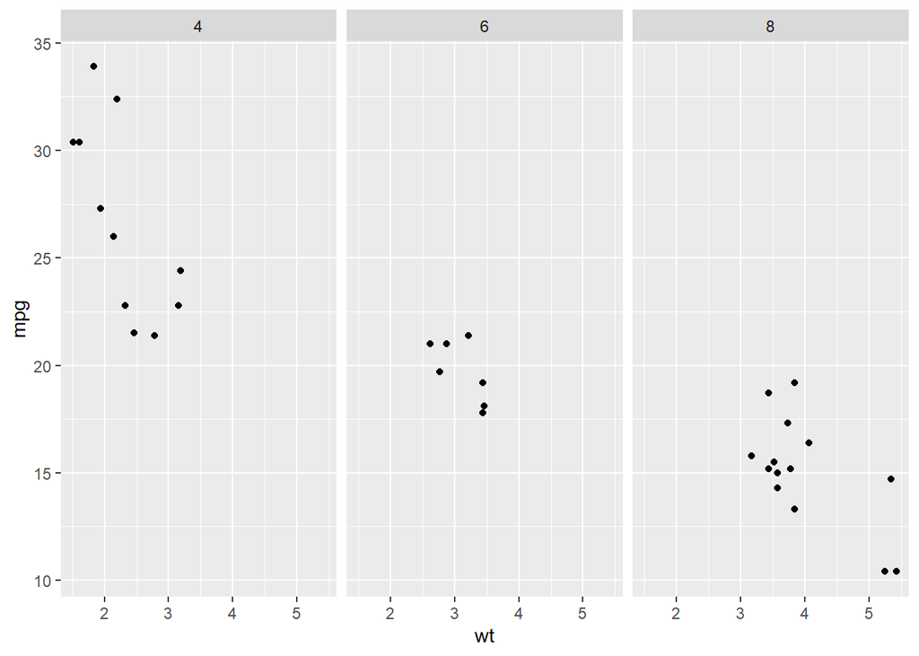

```r
mtcars %>%
  ggplot() +
  geom_point(mapping = aes(wt, mpg),
             fill = "green") +
  facet_wrap(~cyl)
```

# **Troubleshooting Passing Vectors**

You may sometimes have a data set that has many variables containing special characters. In such cases, you may try to pass as arguments to the `x` and `y` aesthetics (viz., `aes()`) the variable names in quotes. If so, `ggplot2` will plot a single point (rather than all xy coordinates).

Let’s see using the `mtcars` data to plot car weight against miles per gallon.

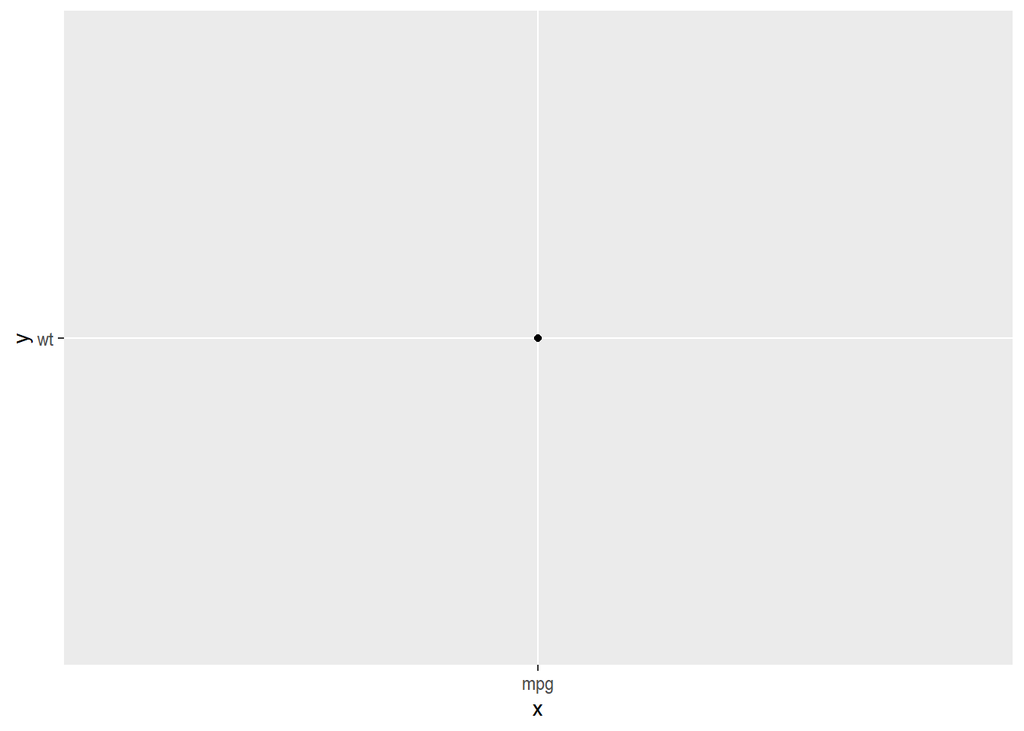

```r
mtcars %>%
    ggplot(.,
       aes(x = "mpg", y = "wt")) + geom_point()
```

This is certainly awkward. You may not even think to just pass the name without quotes but if you did, you would see a nice scatter plot.

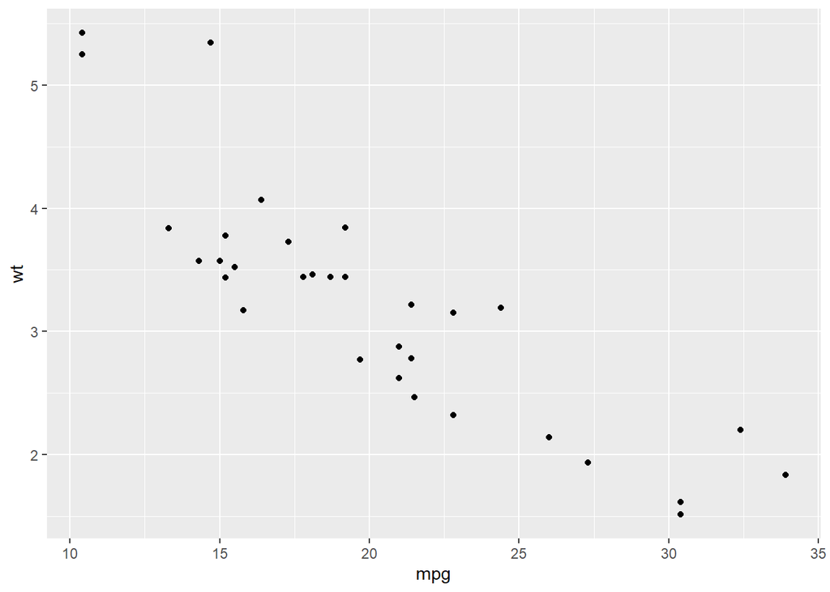

```r
mtcars %>%
    ggplot(.,
       aes(x = mpg, y = wt)) + geom_point()
```

Easy fix if you know what you are doing but there is a larger problem when you have special characters in variable names.

```r
#add new vars
mtcars2 <- mtcars %>%
  mutate(.,
         "_wt" = wt,
         "_mpg" = mpg)
```

This code will produce an error, which unfortunately is not very diagnostic regarding the unexpected symbol. There is no quote in the code but the error seems to be stating there are `"` which are causing problems.

`mtcars2 %>%` `ggplot(.,` `aes(x = _mpg, y = _wt)) + geom_point()`

So what do you do?

You can use the tick (e.g., “`”) to wrap your variable names, though this approach may never come to mind unless you work with RStudio long enough to see that the tick is often wrapped around variable names. Nevertheless, this will solve your problem.

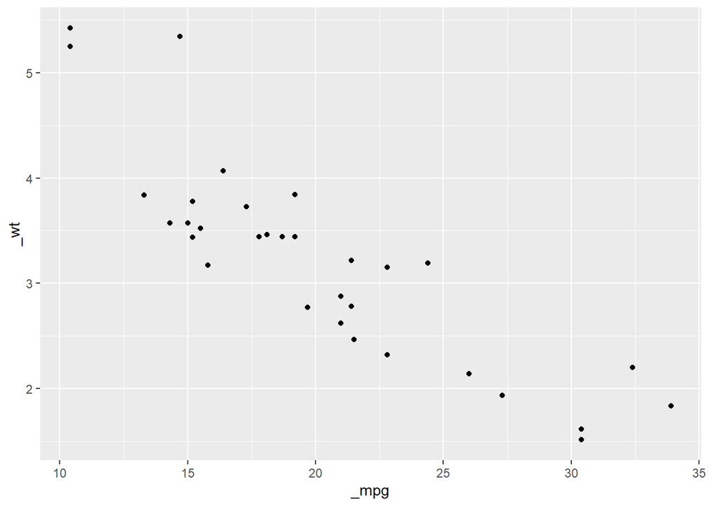

```r
mtcars2 %>%
    ggplot(.,
       aes(x = .data$`_mpg`, y = .data$`_wt`)) + geom_point()
```

Another approach if you are using `%>%`, the `.data` pronoun as part of the `tidyverse` will allow you to pass the quoted name as a the argument by putting it in double square brackets (e.g., `[[]]`)

To see how single or double brackets work on a data frame, both are applied below to the `mtcars2` data frame containing the new variables.

```r
mtcars2["_mpg"]
```

```
##                     _mpg
## Mazda RX4           21.0
## Mazda RX4 Wag       21.0
## Datsun 710          22.8
## Hornet 4 Drive      21.4
## Hornet Sportabout   18.7
## Valiant             18.1
## Duster 360          14.3
## Merc 240D           24.4
## Merc 230            22.8
## Merc 280            19.2
## Merc 280C           17.8
## Merc 450SE          16.4
## Merc 450SL          17.3
## Merc 450SLC         15.2
## Cadillac Fleetwood  10.4
## Lincoln Continental 10.4
## Chrysler Imperial   14.7
## Fiat 128            32.4
## Honda Civic         30.4
## Toyota Corolla      33.9
## Toyota Corona       21.5
## Dodge Challenger    15.5
## AMC Javelin         15.2
## Camaro Z28          13.3
## Pontiac Firebird    19.2
## Fiat X1-9           27.3
## Porsche 914-2       26.0
## Lotus Europa        30.4
## Ford Pantera L      15.8
## Ferrari Dino        19.7
## Maserati Bora       15.0
## Volvo 142E          21.4
```

```r
mtcars2[["_mpg"]]
```

```
##  [1] 21.0 21.0 22.8 21.4 18.7 18.1 14.3 24.4 22.8 19.2 17.8 16.4 17.3 15.2 10.4
## [16] 10.4 14.7 32.4 30.4 33.9 21.5 15.5 15.2 13.3 19.2 27.3 26.0 30.4 15.8 19.7
## [31] 15.0 21.4
```

OK, and for `ggplot2`…

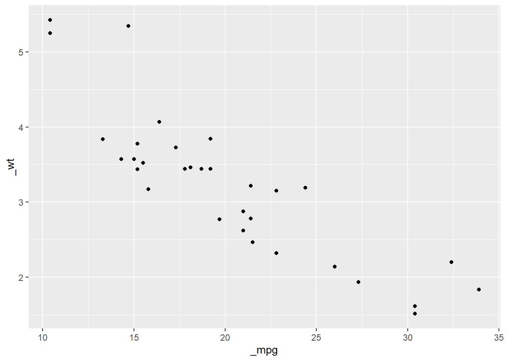

```r
mtcars2 %>%
    ggplot(.,
       aes(x = .data[["_mpg"]], y = .data[["_wt"]])) + geom_point()
```

Note: You could use `.` instead of `.data` to represent the data frame being passed but that is discouraged and may be deprecated (no longer work).

As a general tip when cleaning up variable names, change variables so that they don’t contain characters like “-” or “$” or others that don’t work kindly with some functions. Using “_” is fine except when putting that at the beginning or end of variable name.

# **Setting Themes for Plot Consistency**

Although you can modify the plot theme by adding it as a layer, doing so may be redundant when you do not wish to accept the default theme. Rather that add a theme layer to your plot using `theme_minimal()`, `theme_classic()`, or some other theme, you could set the theme at the top of your code file using `theme_set()`. Then, all plots in the file will adhere to that theme unless you add a layer to change it.

To set the theme to `theme_minimal()`, pass that theme into `theme_set()`. We will often use a theme from the `see` library, `see::theme_modern()`. If set here, all plots after, and only after, setting the theme will abide by those theme characteristics.

```r
theme_set(theme_minimal())

#theme_set(see::theme_modern())
```